# Colonization and Extinction Final Models

This is a cleaned version of 04_24_19 Temp link trait fish.Rmd/11_20_19_Temp_link_traits_fish.Rmd. Changes * improved formatting * easier to follow * species and region as random effects * scaling temperature values * setting nACQ to 0, see why [here](https://stats.stackexchange.com/questions/77313/why-cant-i-match-glmer-family-binomial-output-with-manual-implementation-of-g).

```r
library(MuMIn)
library(lme4)
library(data.table)
library(ggplot2)

load("spp_master_ztemp_seus_buoys.RData")
```

Running, and ranking colonization models without traits

##Here, I scaled all temperature values across all regions, and included species as a random effect. In order to do this, I had to change the algorithm slightly–nAGQ = 0.

```r
#extract just temperature variables to scale
spp_master_ztemp_seus_buoy_varsonly <- spp_master_ztemp_seus_buoy[,c(1,45:292)]

#names of temp variables, so I can add "_scaled" suffix
tempvars <- colnames(spp_master_ztemp_seus_buoy[,45:292])

#scale all variables, make new columns, do this by region
spp_master_ztemp_seus_buoy_varsonly[, paste0(tempvars, "_scaled") := lapply(.SD, function(x) as.vector(scale(x))), .SDcols = tempvars]


#names of scaled columns
scaled_cols <- grep("*_scaled", names(spp_master_ztemp_seus_buoy_varsonly), value = T)

#merge new columns back with spp_master_ztemp_seus_buoy
spp_master_ztemp_seus_buoy_scaled <- cbind(spp_master_ztemp_seus_buoy, spp_master_ztemp_seus_buoy_varsonly[,scaled_cols, with = FALSE])

save(spp_master_ztemp_seus_buoy_scaled, file = "spp_master_ztemp_seus_buoy_scaled.RData")

#going to make loop to make all models I need to look at with single variables
variables_scaled <- colnames(spp_master_ztemp_seus_buoy_scaled[,scaled_cols, with = FALSE])

colonization_model_comparison_spprandom_scaled_seus_update <- as.data.table(matrix(nrow = length(variables_scaled)))
colonization_model_comparison_spprandom_scaled_seus_update[, variable:=as.factor(V1)][, coef:=as.numeric(V1)][, p_value:=as.numeric(V1)][, AICc:=as.numeric(V1)]
colonization_model_comparison_spprandom_scaled_seus_update[, V1 := NULL]

for (i in 1:length(variables_scaled)){
  mod <- glmer(col ~ get(variables_scaled[i]) + (1|reg) + (1|spp), family = binomial, data = spp_master_ztemp_seus_buoy_scaled, nAGQ = 0)
  colonization_model_comparison_spprandom_scaled_seus_update[i,variable := variables_scaled[i]]
  colonization_model_comparison_spprandom_scaled_seus_update[i,coef := coef(summary(mod))[,"Estimate"][2]]
  colonization_model_comparison_spprandom_scaled_seus_update[i,p_value := coef(summary(mod))[,"Pr(>|z|)"][2]]
  colonization_model_comparison_spprandom_scaled_seus_update[i,AICc := AICc(mod)]

  print(paste(i, length(variables_scaled), sep = "/"))

}

#by setting nACQ to 0, all models converged
```

Extinction Models without Traits

```r
#see setup above

extinction_model_comparison_spprandom_scaled_seus_update <- as.data.table(matrix(nrow = length(variables_scaled)))
extinction_model_comparison_spprandom_scaled_seus_update[, variable:=as.factor(V1)][, coef:=as.numeric(V1)][, p_value:=as.numeric(V1)][, AICc:=as.numeric(V1)]
extinction_model_comparison_spprandom_scaled_seus_update[, V1 := NULL]

for (i in 1:length(variables_scaled)){
  mod <- glmer(now_ext ~ get(variables_scaled[i]) + (1|reg) + (1|spp), family = binomial, data = spp_master_ztemp_seus_buoy_scaled, nAGQ = 0)
  extinction_model_comparison_spprandom_scaled_seus_update[i,variable := variables_scaled[i]]
  extinction_model_comparison_spprandom_scaled_seus_update[i,coef := coef(summary(mod))[,"Estimate"][2]]
  extinction_model_comparison_spprandom_scaled_seus_update[i,p_value := coef(summary(mod))[,"Pr(>|z|)"][2]]
  extinction_model_comparison_spprandom_scaled_seus_update[i,AICc := AICc(mod)]

  print(paste(i, length(variables_scaled), sep = "/"))

}

#by setting nACQ to 0, all models converged
```

Relative Variable Importance

```r
colonization_model_comparison_spprandom_scaled_seus_update_nomean <- colonization_model_comparison_spprandom_scaled_seus_update[!grepl("mean",variable),]

colnames(colonization_model_comparison_spprandom_scaled_seus_update_nomean)

extinction_model_comparison_spprandom_scaled_seus_update_nomean <- extinction_model_comparison_spprandom_scaled_seus_update[!grepl("mean",variable),]
```

What about null models?

```r
#add null to tables
interceptcolmod_scaled <- glmer(col ~ (1|spp) + (1|reg), family = binomial, nAGQ = 0, data = spp_master_ztemp_seus_buoy_scaled)

interceptextmod_scaled <- glmer(now_ext ~ (1|reg) + (1|spp), family = binomial, data = spp_master_ztemp_seus_buoy_scaled, nAGQ = 0)


AICc(interceptcolmod_scaled)-min(colonization_model_comparison_spprandom_scaled_seus_update_nomean$AICc)
AICc(interceptextmod_scaled)-min(extinction_model_comparison_spprandom_scaled_seus_update_nomean$AICc)
```

Relative Variable Importance for Colonization Models

```r
#add ∆AIC to tables
min_col_AICc <- min(colonization_model_comparison_spprandom_scaled_seus_update_nomean[, AICc])
colonization_model_comparison_spprandom_scaled_seus_update_nomean[,"deltaAICc" := (AICc - min_col_AICc)]
#add relative likelihood exp( -0.5 * ∆AIC score for that model)
colonization_model_comparison_spprandom_scaled_seus_update_nomean[,"rel_likelihood" := exp((-0.5 * deltaAICc))]
#sum relative likelihoods across all models
colonization_model_comparison_spprandom_scaled_seus_update_nomean.likelihoodsum <- sum(colonization_model_comparison_spprandom_scaled_seus_update_nomean[, rel_likelihood])
#Akaike weight for a model is this rel_likelihood devided by the sum of these values across all models
colonization_model_comparison_spprandom_scaled_seus_update_nomean[,"akaike_weight" := rel_likelihood/colonization_model_comparison_spprandom_scaled_seus_update_nomean.likelihoodsum]
#I want to look at relative importance FOR
#bottom/surface (bottom = includes sbt, grepl("sbt", variable))
col_bottom_importance <- sum(colonization_model_comparison_spprandom_scaled_seus_update_nomean[grep("sbt", variable), ]$akaike_weight)
col_surface_importance <- sum(colonization_model_comparison_spprandom_scaled_seus_update_nomean[grep("sst", variable), ]$akaike_weight)
#lag/not lagged (grepl("lag", variable))
col_lag_importance <- sum(colonization_model_comparison_spprandom_scaled_seus_update_nomean[grep("lag", variable), ]$akaike_weight)
col_nolag_importance <- sum(colonization_model_comparison_spprandom_scaled_seus_update_nomean[!grep("lag", variable), ]$akaike_weight)
#absolute (grepl("abs", variable))
col_abs_importance <- sum(colonization_model_comparison_spprandom_scaled_seus_update_nomean[grep("abs", variable), ]$akaike_weight)
#raw (!grepl("change"))
col_raw_importance <- sum(colonization_model_comparison_spprandom_scaled_seus_update_nomean[!grep("change", variable), ]$akaike_weight)
#change (grepl("change", variable), (!grepl("abs")))
col_change_importance <- sum(colonization_model_comparison_spprandom_scaled_seus_update_nomean[grep("change", variable), ][!grep("abs", variable),]$akaike_weight)
#type of temp variable (max, min, seas)
col_max_temp_importance <- sum(colonization_model_comparison_spprandom_scaled_seus_update_nomean[grep("max", variable), ]$akaike_weight)
col_min_temp_importance <- sum(colonization_model_comparison_spprandom_scaled_seus_update_nomean[grep("min", variable), ]$akaike_weight)
col_seas_temp_importance <- sum(colonization_model_comparison_spprandom_scaled_seus_update_nomean[grep("seas", variable), ]$akaike_weight)
save(colonization_model_comparison_spprandom_scaled_seus_update_nomean, file = "colonization_model_comparison_spprandom_scaled_seus_update_nomean.RData")
```

Relative Variable Importance for Pairs of Transformation and Metric

```r
#I want to look at relative importance FOR
#models with raw and min
col_raw_min_importance <- sum(colonization_model_comparison_spprandom_scaled_seus_update_nomean[grep("min", variable), ][!grep("change", variable)]$akaike_weight)
#models with raw and max
col_raw_max_importance <- sum(colonization_model_comparison_spprandom_scaled_seus_update_nomean[grep("max", variable), ][!grep("change", variable)]$akaike_weight)
#models with raw and seas
col_raw_seas_importance <- sum(colonization_model_comparison_spprandom_scaled_seus_update_nomean[grep("seas", variable), ][!grep("change", variable)]$akaike_weight)
#models with change and min
col_change_min_importance <- sum(colonization_model_comparison_spprandom_scaled_seus_update_nomean[grep("min_s.t_temp_change", variable), ][!grep("abs", variable)]$akaike_weight)
#models with change and max
col_change_max_importance <- sum(colonization_model_comparison_spprandom_scaled_seus_update_nomean[grep("max_s.t_temp_change", variable), ][!grep("abs", variable)]$akaike_weight)
#models with change and seas
col_change_seas_importance <- sum(colonization_model_comparison_spprandom_scaled_seus_update_nomean[grep("seas_s.t_temp_change", variable), ][!grep("abs", variable)]$akaike_weight)
#models with abs change and min
col_abs_change_min_importance <- sum(colonization_model_comparison_spprandom_scaled_seus_update_nomean[grep("min_s.t_temp_change_abs", variable), ]$akaike_weight)
#models with abs change and max
col_abs_change_max_importance <- sum(colonization_model_comparison_spprandom_scaled_seus_update_nomean[grep("max_s.t_temp_change_abs", variable), ]$akaike_weight)
#models with abs change and seas
col_abs_change_seas_importance <- sum(colonization_model_comparison_spprandom_scaled_seus_update_nomean[grep("seas_s.t_temp_change_abs", variable), ]$akaike_weight)
col_transform_metric_comparison <- data.table(Transformation =
                                                c("raw", "raw", "raw", "change", "change", "change", "abs_change", "abs_change", "abs_change"),
                                              Metric =
                                                rep(c("min", "max", "seas"), 3),
                                              RVI =
                                                c(col_raw_min_importance, col_raw_max_importance,
                                                  col_raw_seas_importance, col_change_min_importance,
                                                  col_change_max_importance, col_change_seas_importance,
                                                  col_abs_change_min_importance, col_abs_change_max_importance,
                                                  col_abs_change_seas_importance))
```

Relative Variable Importance for Extinction Models

```r
load("colonization_model_comparison_spprandom_scaled_seus_update_nomean.RData")
#add ∆AIC to tables
min_ext_AICc <- min(extinction_model_comparison_spprandom_scaled_seus_update_nomean[, AICc])
extinction_model_comparison_spprandom_scaled_seus_update_nomean[,"deltaAICc" := (AICc - min_ext_AICc)]
#add relative likelihood exp( -0.5 * ∆AIC score for that model)
extinction_model_comparison_spprandom_scaled_seus_update_nomean[,"rel_likelihood" := exp((-0.5 * deltaAICc))]
#sum relative likelihoods across all models
extinction_model_comparison_spprandom_scaled_seus_update_nomean.likelihoodsum <- sum(extinction_model_comparison_spprandom_scaled_seus_update_nomean[, rel_likelihood])
#Akaike weight for a model is this rel_likelihood devided by the sum of these values across all models
extinction_model_comparison_spprandom_scaled_seus_update_nomean[,"akaike_weight" := rel_likelihood/extinction_model_comparison_spprandom_scaled_seus_update_nomean.likelihoodsum]
#I want to look at relative importance FOR
#bottom/surface (bottom = includes sbt, grepl("sbt", variable))
ext_bottom_importance <- sum(extinction_model_comparison_spprandom_scaled_seus_update_nomean[grep("sbt", variable), ]$akaike_weight)
ext_surface_importance <- sum(extinction_model_comparison_spprandom_scaled_seus_update_nomean[grep("sst", variable), ]$akaike_weight)
#lag/not lagged (grepl("lag", variable))
ext_lag_importance <- sum(extinction_model_comparison_spprandom_scaled_seus_update_nomean[grep("lag", variable), ]$akaike_weight)
ext_nolag_importance <- sum(extinction_model_comparison_spprandom_scaled_seus_update_nomean[!grep("lag", variable), ]$akaike_weight)
#absolute (grepl("abs", variable))
ext_abs_importance <- sum(extinction_model_comparison_spprandom_scaled_seus_update_nomean[grep("abs", variable), ]$akaike_weight)
#raw (!grepl("change"))
ext_raw_importance <- sum(extinction_model_comparison_spprandom_scaled_seus_update_nomean[!grep("change", variable), ]$akaike_weight)
#change (grepl("change", variable), (!grepl("abs")))
ext_change_importance <- sum(extinction_model_comparison_spprandom_scaled_seus_update_nomean[grep("change", variable), ][!grep("abs", variable),]$akaike_weight)
#type of temp variable (max, min, seas)
ext_max_temp_importance <- sum(extinction_model_comparison_spprandom_scaled_seus_update_nomean[grep("max", variable), ]$akaike_weight)
ext_min_temp_importance <- sum(extinction_model_comparison_spprandom_scaled_seus_update_nomean[grep("min", variable), ]$akaike_weight)
ext_seas_temp_importance <- sum(extinction_model_comparison_spprandom_scaled_seus_update_nomean[grep("seas", variable), ]$akaike_weight)
save(extinction_model_comparison_spprandom_scaled_seus_update_nomean, file = "extinction_model_comparison_spprandom_scaled_seus_update_nomean.RData")
```

Relative Variable Importance for Pairs of Transformation and Metric

```r
#I want to look at relative importance FOR
#models with raw and min
ext_raw_min_importance <- sum(extinction_model_comparison_spprandom_scaled_seus_update_nomean[grep("min", variable), ][!grep("change", variable)]$akaike_weight)
#models with raw and max
ext_raw_max_importance <- sum(extinction_model_comparison_spprandom_scaled_seus_update_nomean[grep("max", variable), ][!grep("change", variable)]$akaike_weight)
#models with raw and seas
ext_raw_seas_importance <- sum(extinction_model_comparison_spprandom_scaled_seus_update_nomean[grep("seas", variable), ][!grep("change", variable)]$akaike_weight)
#models with change and min
ext_change_min_importance <- sum(extinction_model_comparison_spprandom_scaled_seus_update_nomean[grep("min_s.t_temp_change", variable), ][!grep("abs", variable)]$akaike_weight)
#models with change and max
ext_change_max_importance <- sum(extinction_model_comparison_spprandom_scaled_seus_update_nomean[grep("max_s.t_temp_change", variable), ][!grep("abs", variable)]$akaike_weight)
#models with change and seas
ext_change_seas_importance <- sum(extinction_model_comparison_spprandom_scaled_seus_update_nomean[grep("seas_s.t_temp_change", variable), ][!grep("abs", variable)]$akaike_weight)
#models with abs change and min
ext_abs_change_min_importance <- sum(extinction_model_comparison_spprandom_scaled_seus_update_nomean[grep("min_s.t_temp_change_abs", variable), ]$akaike_weight)
#models with abs change and max
ext_abs_change_max_importance <- sum(extinction_model_comparison_spprandom_scaled_seus_update_nomean[grep("max_s.t_temp_change_abs", variable), ]$akaike_weight)
#models with abs change and seas
ext_abs_change_seas_importance <- sum(extinction_model_comparison_spprandom_scaled_seus_update_nomean[grep("seas_s.t_temp_change_abs", variable), ]$akaike_weight)
ext_transform_metric_comparison <- data.table(Transformation =
                                                c("raw", "raw", "raw", "change", "change", "change", "abs_change", "abs_change", "abs_change"),
                                              Metric =
                                                rep(c("min", "max", "seas"), 3),
                                              RVI =
                                                c(ext_raw_min_importance, ext_raw_max_importance,
                                                  ext_raw_seas_importance, ext_change_min_importance,
                                                  ext_change_max_importance, ext_change_seas_importance,
                                                  ext_abs_change_min_importance, ext_abs_change_max_importance,
                                                  ext_abs_change_seas_importance))
```

Let’s see how the RVI importance varies by looking at specific lag values

[figure not shown]

Table for RVI data for Colonization

```r
col_ext <- c("col","col","col","col","col", "col","col", "col", "col","col","col","col","col","col", "col","col", "col", "col","col")
type <- c("Depth", "Depth", "lag", "lag", "Transformation", "Transformation", "Transformation", "Metric", "Metric", "Metric", "Transformation x Metric", "Transformation x Metric", "Transformation x Metric", "Transformation x Metric", "Transformation x Metric", "Transformation x Metric", "Transformation x Metric", "Transformation x Metric", "Transformation x Metric")
variable <- c("Bottom", "Surface", "no_lag", "lagged", "|Change|", "Change", "Raw", "Min", "Max", "Seas", "Raw x Min", "Raw x Max", "Raw x Seas", "Change x Min", "Change x Max", "Change x Seas", "|Change| x Min", "|Change| x Max", "|Change| x Seas")
value <- c(col_bottom_importance, col_surface_importance, col_nolag_importance, col_lag_importance, col_abs_importance, col_change_importance, col_raw_importance, col_min_temp_importance, col_max_temp_importance, col_seas_temp_importance, col_raw_min_importance, col_raw_max_importance, col_raw_seas_importance, col_change_min_importance, col_change_max_importance, col_change_seas_importance, col_abs_change_min_importance, col_abs_change_max_importance, col_abs_change_seas_importance)
RVI_col <- data.table(col_ext, type, variable, value)
```

Table for RVI data for Extinction

[output not shown]

[output cut: 9 more lines]

Merge RVI tables for colonization and extinction, and then graph

```r
RVI_table <- as.data.table(rbind(RVI_col, RVI_ext)) #bind RVI for colonizations and extinctions

RVI_table.r <- RVI_table[!grep("Surface", variable)][!grep("lagged", variable)]

#change order of factor levels
RVI_table.r[, variable := factor(variable, levels = c("Bottom", "no_lag", "Raw", "Change", "|Change|", "Min", "Max", "Seas"))]

save(RVI_table, file = "RVI_table.Rdata")

ggplot(data = RVI_table.r, aes(x=variable, y = value, fill = col_ext)) +
  geom_bar(stat = "identity", position = "dodge") +
  scale_x_discrete(breaks = c("Bottom", "no_lag", "Raw", "Change", "|Change|", "Min", "Max", "Seas"),
                   labels = c("Bottom Temp", "No Lag", "Raw Temp", "Change in \nTemp", "| Change in\n Temp |", "Min Temp", "Max Temp", "Seas")) +
  labs(x = "Temperature Variables", y = "Relative Variable Importance")  +
  theme_bw()
```

Another way to visualize is stacked bar plot.

```r
colors
```

[output not shown]

Let’s look at just Depth and Transformation x Metric

[figure not shown]

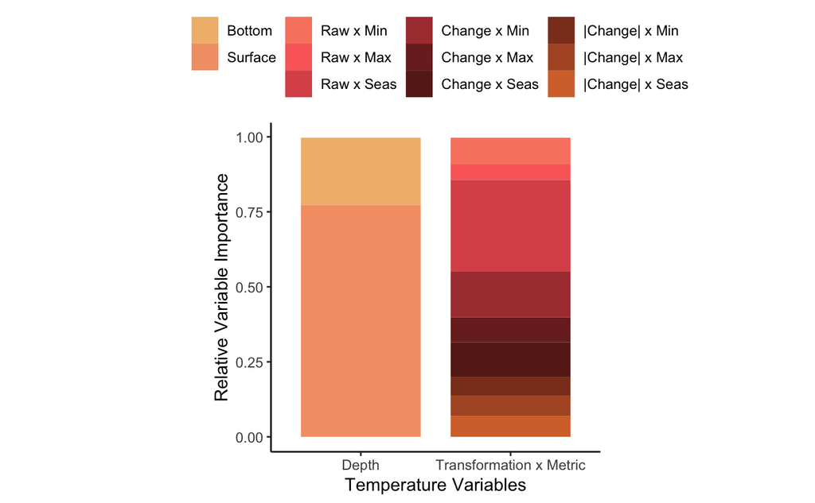

```r
colonization_max_abs_change_avg_coef
```

```
[1] -0.2878733
```

```r
extinction_seas_change_avg_coef
```

```
[1] -0.1067347
```

How well do these models actually predict the # of colonizations and the # of extinctions?

```r
library(tidyr)
library(plyr)
#best colonization models (all delta less than 2)
  #seas_sst_temp_scaled
  #max_sst_temp_change_abs_lag1_scaled



bestcolmod_scaled <- glmer(col ~ seas_sst_temp_scaled + (1|reg) + (1|spp), family = binomial, data = spp_master_ztemp_seus_buoy_scaled, nAGQ = 0)

interceptcolmod_scaled <- glmer(col ~ (1|reg) + (1|spp), family = binomial, data = spp_master_ztemp_seus_buoy_scaled, nAGQ = 0)


#I wanted predicted # of colonizations in each region per region/year
#year region observed colonizations predicted colonizations

#plotting predicted versus modeled
#unique combinations of spp, region, and max_sbt_temp_change_abs_scaled found in dataset
model_imputs <- spp_master_ztemp_seus_buoy_scaled[,c("spp", "reg", "year", "col", "now_ext", "seas_sst_temp_scaled")]

t2_col <- predict(bestcolmod_scaled, newdata = model_imputs, type = "response", re.form = NULL) #setting re.form to NULL includes all random effects

t2_col_null <- predict(interceptcolmod_scaled, newdata = model_imputs, type = "response", re.form = NULL) #setting re.form to NULL includes all random effects

model_imputs$pred <- t2_col
model_imputs$pred_null <- t2_col_null

#group by region and year, sum over "col" = observations, and "pred" = predict colonizations by summing probabilities
col_model_comparisons <- model_imputs[, .(col_predicted = sum(pred), col_predicted_null = sum(pred_null), col_observed = sum(col)), by=.(year,reg)]


ggplot(aes(x=year), data = col_model_comparisons) +
  geom_point(aes(y = col_observed), data = col_model_comparisons, col = "red") +
  geom_point(data = col_model_comparisons, aes(y = col_predicted), col = "black") +
#  geom_point(data = col_model_comparisons, aes(y = col_predicted_null), col = "blue") +
  facet_wrap(~reg) +
  theme_classic()
```

Instead, I want to look at these with accumulation of colonizations

```r
col_model_comparisons[,col_obs_sum := cumsum(col_observed), by = reg]
col_model_comparisons[,col_pred_sum := cumsum(col_predicted), by = reg]
col_model_comparisons[,col_pred_sum_null := cumsum(col_predicted_null), by = reg]

ggplot(aes(x=year), data = col_model_comparisons) +
  geom_point(aes(y = col_obs_sum), data = col_model_comparisons, col = "red") +
  geom_point(data = col_model_comparisons, aes(y = col_pred_sum), col = "black", size = 1) +
  geom_point(data = col_model_comparisons, aes(y = col_pred_sum_null), col = "blue", size = 1) +
  labs(x="Year", y = "Cumulative sum of colonizations") +
  facet_wrap(~reg) +
  theme_classic()
```

```r
#best extinction model (all delta less than 2)
  #seas_sst_temp_lag3_scaled
  #min_sst_temp_change_lag2_scaled


bestextmod_scaled <- glmer(now_ext ~ seas_sst_temp_lag3_scaled + (1|reg) + (1|spp), family = binomial, data = spp_master_ztemp_seus_buoy_scaled, nAGQ = 0)

interceptextmod_scaled <- glmer(now_ext ~ (1|reg) + (1|spp), family = binomial, data = spp_master_ztemp_seus_buoy_scaled, nAGQ = 0)

#I wanted predicted # of colonizations in each region per region/year
#year region observed colonizations predicted colonizations

#plotting predicted versus modeled
#unique combinations of spp, region, and max_sbt_temp_change_abs_scaled found in dataset
model_imputs <- spp_master_ztemp_seus_buoy_scaled[,c("spp", "reg", "year", "col", "now_ext", "seas_sst_temp_lag3_scaled")]

t2_ext <- predict(bestextmod_scaled, newdata = model_imputs, type = "response", re.form = NULL) #setting re.form to NULL includes all random effects
t2_ext_null <- predict(interceptextmod_scaled, newdata = model_imputs, type = "response", re.form = NULL) #setting re.form to NULL includes all random effects

model_imputs$pred <- t2_ext
model_imputs$pred_null <- t2_ext_null

#group by region and year, sum over "ext" = observations, and "pred" = predict colonizations by summing probabilities
ext_model_comparisons <- model_imputs[, .(ext_predicted = sum(pred), ext_predicted_null = sum(pred_null), ext_observed = sum(now_ext)), by=.(year,reg)]


ggplot(aes(x=year), data = ext_model_comparisons) +
  geom_point(aes(y = ext_observed), data = ext_model_comparisons, col = "red") +
  geom_point(data = ext_model_comparisons, aes(y = ext_predicted), col = "black") +
  geom_point(data = ext_model_comparisons, aes(y=ext_predicted_null), col = "blue") +
  facet_wrap(~reg) +
  theme_classic()
```

Instead, I want to look at these with accumulation of extinctions

```r
ext_model_comparisons[,ext_obs_sum := cumsum(ext_observed), by = reg]
ext_model_comparisons[,ext_pred_sum := cumsum(ext_predicted), by = reg]
ext_model_comparisons[,ext_pred_sum_null := cumsum(ext_predicted_null), by = reg]

ggplot(aes(x=year), data = ext_model_comparisons) +
  geom_point(aes(y = ext_obs_sum), data = ext_model_comparisons, col = "red") +
  geom_point(data = ext_model_comparisons, aes(y = ext_pred_sum), col = "black", size = 1) +
  geom_point(data = ext_model_comparisons, aes(y = ext_pred_sum_null), col = "blue", size = 0.5) +
  labs(x="Year", y = "Cumulative sum of extinctions") +
  facet_wrap(~reg) +
  theme_classic()
```

Cumulative species richness change

```r
#from colonizations
cumulative_richness <- col_model_comparisons[,.(reg, year, col_obs_sum, col_pred_sum, col_pred_sum_null)]
ext_obs_sum <- ext_model_comparisons[,.(ext_obs_sum)]
ext_pred_sum <- ext_model_comparisons[,.(ext_pred_sum)]
ext_pred_sum_null <- ext_model_comparisons[,.(ext_pred_sum_null)]
cumulative_richness[,ext_obs_sum := ext_obs_sum]
cumulative_richness[,ext_pred_sum := ext_pred_sum]
cumulative_richness[,ext_pred_sum_null := ext_pred_sum_null]

cumulative_richness[, Observed := col_obs_sum-ext_obs_sum][, Predicted := col_pred_sum-ext_pred_sum][, Predicted_null := col_pred_sum_null - ext_pred_sum_null]

cumulative_richness.r <- cumulative_richness[,.(reg, year, Observed, Predicted, Predicted_null)]

#wide to long
cumulative_richness.r <- melt(cumulative_richness.r, id.vars = c("reg", "year"), measure.vars = c("Observed", "Predicted", "Predicted_null"), variable.name = "Richness", value.name = "value")



#rename region levels for plotting
levels(cumulative_richness.r$reg) <- c("Aleutian Islands", "E. Bering Sea", "Gulf of Mexico", "Gulf of Alaska", "Northeast US", "Newfoundland", "Southeast US", "Scotian Shelf", "West Coast US")

#plot richness over time predicted versus observed
cum_richness_plot <- ggplot(aes(x=year, y = value, color = Richness, shape = Richness), data = cumulative_richness.r) +
  geom_point(size = 2) +
  geom_hline(yintercept = 0) +
  labs(x="Year", y = "Cumulative Richness") +
  facet_wrap(~reg, scales = "free_y") +
  theme_classic() +
  scale_color_manual(values = c("Observed" = 'coral3' , "Predicted" = 'deepskyblue4', "Predicted_null" = 'black')) +
  scale_shape_manual(values = c("Observed" = 19 , "Predicted" = 19, "Predicted_null" = 20)) +
  theme(plot.title = element_text(size = 17),
        legend.title = element_text(size = 17),
        legend.text=element_text(size = 15),
        strip.text = element_text(size = 12),
        axis.title = element_text(size = 14))

cum_richness_plot

ggsave(cum_richness_plot, file = "cum_richness_plot.jpg")
ggsave(cum_richness_plot, file = "cum_richness_plot.eps")

?ggsave
```

Another plot looking only at observed cumulative richness, and NOT predicted richness.

```r
library(dplyr)

#pull col/ext from spp master
spp_master_ztemp_seus_buoy.r <- spp_master_ztemp_seus_buoy[,.(col_count = sum(col, na.rm = T), ext_count = sum(now_ext, na.rm = T), observations = .N), by = .(reg, year)][, richness_yearly := col_count-ext_count][ ,cumulative_richness := cumsum(richness_yearly), by = .(reg)]

levels(spp_master_ztemp_seus_buoy.r[,reg])

#rename levels for plotting and linking to hauls
setattr(spp_master_ztemp_seus_buoy.r[["reg"]],"levels",c("Aleutian Islands", "E. Bering Sea", "Gulf of Mexico", "Gulf of Alaska", "Northeast US", "Newfoundland", "Southeast US", "Scotian Shelf", "West Coast US"))



#plot
cum_richness_plot <- ggplot(aes(x=year), data = spp_master_ztemp_seus_buoy.r) +
  geom_point(aes(y = cumulative_richness), pch = 20) +
  geom_hline(yintercept = 0) +
  labs(x="Year", y = "Cumulative Richness") +
  facet_wrap(~reg, scales = c("free"))+
  theme_classic()

cum_richness_plot
```

```r
region_observations <- spp_master_ztemp_seus_buoy.r[,.(obs_yearly = mean(observations)), by = .(reg)]
reg_obs_plot <- ggplot(data = region_observations, aes(x = reg, y = obs_yearly)) +
  geom_bar(stat = "identity", width = 0.9, color = "black", fill = "black") +
  ylab("Species in Region") +
  xlab("Region") +
  theme_classic() +
  theme(axis.text.x = element_text(angle = 90))

library(gridExtra)
grid.arrange(cum_richness_plot, reg_obs_plot, ncol = 1, nrow = 2, heights =  c(3/5,2/5))

ggsave(width = 10, height = 8, file = "cumrichnessplot.jpg")
```

In response to plots above, Malin: “Perhaps worth one more set of plots to understand what’s going on: each point would be a year, x-axis would be observed change in richness, y-axis would be predicted change in richness. One set of plots for each of the three models (null, temp, temp+trait), each sub-plot would be a region, as you have here.”

```r
setkey(cumulative_richness.r, Richness, reg, year)
cumulative_richness.r[, delta_value := value-shift(value), by = .(reg, Richness)]

#have to cast to wide to make x = observed change and y = predicted change
cumulative_richness.r.w <- dcast(cumulative_richness.r, reg + year ~ Richness, value.var = "delta_value")
```

```r
#plot richness over time predicted null versus observed
delta_richness_plot_null <- ggplot(data = cumulative_richness.r.w, aes(x = Observed, y = Predicted_null)) +
  geom_point() +
  labs(x="Observed Change\nin Richness", y = "Predicted Change in\nRichness (Null Model)") +
  facet_wrap(~reg) +
  theme_classic() +
  geom_abline(intercept = 0, slope = 1, color = "grey", linetype = "dashed") +
  theme(plot.title = element_text(size = 17),
        legend.title = element_text(size = 17),
        legend.text=element_text(size = 15),
        strip.text = element_text(size = 12),
        axis.title = element_text(size = 14))

delta_richness_plot_null

#plot richness over time predicted versus observed
delta_richness_plot <- ggplot(data = cumulative_richness.r.w, aes(x = Observed, y = Predicted)) +
  geom_point() +
  labs(x="Observed Change\nin Richness", y = "Predicted Change in\nRichness (Temperature Model)") +
  facet_wrap(~reg) +
  theme_classic() +
  geom_abline(intercept = 0, slope = 1, color = "grey", linetype = "dashed") +
  theme(plot.title = element_text(size = 17),
        legend.title = element_text(size = 17),
        legend.text=element_text(size = 15),
        strip.text = element_text(size = 12),
        axis.title = element_text(size = 14))

delta_richness_plot

ggsave(delta_richness_plot_null, file = "delta_richness_plot_null.jpg")
ggsave(delta_richness_plot, file = "delta_richness_plot.jpg")
```

Running, and ranking colonization models without traits

```r
#going to make loop to make all models I need to look at with single variables
variables <- grep("_s.t_", names(spp_master_ztemp_seus_buoy), value = T)

colonization_model_comparison_spprandom <- as.data.table(matrix(nrow = length(variables)))
colonization_model_comparison_spprandom[, variable:=as.factor(V1)][, coef:=as.numeric(V1)][, p_value:=as.numeric(V1)][, AICc:=as.numeric(V1)]
colonization_model_comparison_spprandom[, V1 := NULL]

for (i in 1:length(variables)){
  mod <- glmer(col ~ get(variables[i]) + (1|reg) + (1|spp), family = binomial, data = spp_master_ztemp_seus_buoy, nAGQ = 0)
  colonization_model_comparison_spprandom[i,variable := variables[i]]
  colonization_model_comparison_spprandom[i,coef := coef(summary(mod))[,"Estimate"][2]]
  colonization_model_comparison_spprandom[i,p_value := coef(summary(mod))[,"Pr(>|z|)"][2]]
  colonization_model_comparison_spprandom[i,AICc := AICc(mod)]

  print(paste(i, length(variables), sep = "/"))

}

#by setting nACQ to 0, all models converged


col_mod_null <- glmer(col ~ (1|reg) + (1|spp), family = binomial, data = spp_master_ztemp_seus_buoy, nAGQ = 0)
AICc(col_mod_null)-min(colonization_model_comparison_spprandom$AICc)
```

Extinction Models without Traits, NOT scaled

```r
#see setup above

extinction_model_comparison_spprandom <- as.data.table(matrix(nrow = length(variables)))
extinction_model_comparison_spprandom[, variable:=as.factor(V1)][, coef:=as.numeric(V1)][, p_value:=as.numeric(V1)][, AICc:=as.numeric(V1)]
extinction_model_comparison_spprandom[, V1 := NULL]

for (i in 1:length(variables)){
  mod <- glmer(now_ext ~ get(variables[i]) + (1|reg) + (1|spp), family = binomial, data = spp_master_ztemp_seus_buoy, nAGQ = 0)
  extinction_model_comparison_spprandom[i,variable := variables[i]]
  extinction_model_comparison_spprandom[i,coef := coef(summary(mod))[,"Estimate"][2]]
  extinction_model_comparison_spprandom[i,p_value := coef(summary(mod))[,"Pr(>|z|)"][2]]
  extinction_model_comparison_spprandom[i,AICc := AICc(mod)]

  print(paste(i, length(variables), sep = "/"))

}

#by setting nACQ to 0, all models converged
```

Relative Variable Importance

```r
colonization_model_comparison_spprandom_nomean <- colonization_model_comparison_spprandom[!grepl("mean",variable),]

extinction_model_comparison_spprandom_nomean <- extinction_model_comparison_spprandom[!grepl("mean",variable),]

#comparison to null
col_mod_null <- glmer(col ~ (1|reg) + (1|spp), family = binomial, data = spp_master_ztemp_seus_buoy, nAGQ = 0)
AICc(col_mod_null)-min(colonization_model_comparison_spprandom$AICc)

ext_mod_null <- glmer(ext ~ (1|reg) + (1|spp), family = binomial, data = spp_master_ztemp_seus_buoy, nAGQ = 0)
AICc(ext_mod_null)-min(extinction_model_comparison_spprandom$AICc)
```

Relative Variable Importance for Colonization Models

```r
#add ∆AIC to tables
min_col_AICc <- min(colonization_model_comparison_spprandom_nomean[, AICc])
colonization_model_comparison_spprandom_nomean[,"deltaAICc" := (AICc - min_col_AICc)]

#add relative likelihood exp( -0.5 * ∆AIC score for that model)
colonization_model_comparison_spprandom_nomean[,"rel_likelihood" := exp((-0.5 * deltaAICc))]
#sum relative likelihoods across all models
colonization_model_comparison_spprandom_nomean.likelihoodsum <- sum(colonization_model_comparison_spprandom_nomean[, rel_likelihood])
#Akaike weight for a model is this rel_likelihood devided by the sum of these values across all models
colonization_model_comparison_spprandom_nomean[,"akaike_weight" := rel_likelihood/colonization_model_comparison_spprandom_nomean.likelihoodsum]

#I want to look at relative importance FOR
#bottom/surface (bottom = includes sbt, grepl("sbt", variable))
col_bottom_importance <- sum(colonization_model_comparison_spprandom_nomean[grep("sbt", variable), ]$akaike_weight)
col_surface_importance <- sum(colonization_model_comparison_spprandom_nomean[grep("sst", variable), ]$akaike_weight)

#lag/not lagged (grepl("lag", variable))
col_lag_importance <- sum(colonization_model_comparison_spprandom_nomean[grep("lag", variable), ]$akaike_weight)
col_nolag_importance <- sum(colonization_model_comparison_spprandom_nomean[!grep("lag", variable), ]$akaike_weight)

#absolute (grepl("abs", variable))
col_abs_importance <- sum(colonization_model_comparison_spprandom_nomean[grep("abs", variable), ]$akaike_weight)

#raw (!grepl("change"))
col_raw_importance <- sum(colonization_model_comparison_spprandom_nomean[!grep("change", variable), ]$akaike_weight)

#change (grepl("change", variable), (!grepl("abs")))
col_change_importance <- sum(colonization_model_comparison_spprandom_nomean[grep("change", variable), ][!grep("abs", variable),]$akaike_weight)

#type of temp variable (max, min, seas)
col_max_temp_importance <- sum(colonization_model_comparison_spprandom_nomean[grep("max", variable), ]$akaike_weight)
col_min_temp_importance <- sum(colonization_model_comparison_spprandom_nomean[grep("min", variable), ]$akaike_weight)
col_seas_temp_importance <- sum(colonization_model_comparison_spprandom_nomean[grep("seas", variable), ]$akaike_weight)
```

Relative Variable Importance for Extinction Models

```r
#add ∆AIC to tables
min_ext_AICc <- min(extinction_model_comparison_spprandom_nomean[, AICc])
extinction_model_comparison_spprandom_nomean[,"deltaAICc" := (AICc - min_ext_AICc)]

#add relative likelihood exp( -0.5 * ∆AIC score for that model)
extinction_model_comparison_spprandom_nomean[,"rel_likelihood" := exp((-0.5 * deltaAICc))]
#sum relative likelihoods across all models
extinction_model_comparison_spprandom_nomean.likelihoodsum <- sum(extinction_model_comparison_spprandom_nomean[, rel_likelihood])
#Akaike weight for a model is this rel_likelihood devided by the sum of these values across all models
extinction_model_comparison_spprandom_nomean[,"akaike_weight" := rel_likelihood/extinction_model_comparison_spprandom_nomean.likelihoodsum]

#I want to look at relative importance FOR
#bottom/surface (bottom = includes sbt, grepl("sbt", variable))
ext_bottom_importance <- sum(extinction_model_comparison_spprandom_nomean[grep("sbt", variable), ]$akaike_weight)
ext_surface_importance <- sum(extinction_model_comparison_spprandom_nomean[grep("sst", variable), ]$akaike_weight)

#lag/not lagged (grepl("lag", variable))
ext_lag_importance <- sum(extinction_model_comparison_spprandom_nomean[grep("lag", variable), ]$akaike_weight)
ext_nolag_importance <- sum(extinction_model_comparison_spprandom_nomean[!grep("lag", variable), ]$akaike_weight)

#absolute (grepl("abs", variable))
ext_abs_importance <- sum(extinction_model_comparison_spprandom_nomean[grep("abs", variable), ]$akaike_weight)

#raw (!grepl("change"))
ext_raw_importance <- sum(extinction_model_comparison_spprandom_nomean[!grep("change", variable), ]$akaike_weight)

#change (grepl("change", variable), (!grepl("abs")))
ext_change_importance <- sum(extinction_model_comparison_spprandom_nomean[grep("change", variable), ][!grep("abs", variable),]$akaike_weight)

#type of temp variable (max, min, seas)
ext_max_temp_importance <- sum(extinction_model_comparison_spprandom_nomean[grep("max", variable), ]$akaike_weight)
ext_min_temp_importance <- sum(extinction_model_comparison_spprandom_nomean[grep("min", variable), ]$akaike_weight)
ext_seas_temp_importance <- sum(extinction_model_comparison_spprandom_nomean[grep("seas", variable), ]$akaike_weight)
```

Let’s see how the RVI importance varies by looking at specific lag values

```r
#first, table for lags
lags_v_RVI_spprandom <- data.table(col_lag = c(0:9), col_RVI = 0, ext_RVI = 0)
#colonization
lags_v_RVI_spprandom[1,2] <- 1-sum(colonization_model_comparison_spprandom_nomean[grep("lag", variable), ]$akaike_weight)
lags_v_RVI_spprandom[2,2] <- sum(colonization_model_comparison_spprandom_nomean[grep("lag1", variable), ]$akaike_weight)
lags_v_RVI_spprandom[3,2] <- sum(colonization_model_comparison_spprandom_nomean[grep("lag2", variable), ]$akaike_weight)
lags_v_RVI_spprandom[4,2] <- sum(colonization_model_comparison_spprandom_nomean[grep("lag3", variable), ]$akaike_weight)
lags_v_RVI_spprandom[5,2] <- sum(colonization_model_comparison_spprandom_nomean[grep("lag4", variable), ]$akaike_weight)
lags_v_RVI_spprandom[6,2] <- sum(colonization_model_comparison_spprandom_nomean[grep("lag5", variable), ]$akaike_weight)
lags_v_RVI_spprandom[7,2] <- sum(colonization_model_comparison_spprandom_nomean[grep("lag6", variable), ]$akaike_weight)
lags_v_RVI_spprandom[8,2] <- sum(colonization_model_comparison_spprandom_nomean[grep("lag7", variable), ]$akaike_weight)
lags_v_RVI_spprandom[9,2] <- sum(colonization_model_comparison_spprandom_nomean[grep("lag8", variable), ]$akaike_weight)
lags_v_RVI_spprandom[10,2] <- sum(colonization_model_comparison_spprandom_nomean[grep("lag9", variable), ]$akaike_weight)
#extinction
lags_v_RVI_spprandom[1,3] <- 1-sum(extinction_model_comparison_spprandom_nomean[grep("lag", variable), ]$akaike_weight)
lags_v_RVI_spprandom[2,3] <- sum(extinction_model_comparison_spprandom_nomean[grep("lag1", variable), ]$akaike_weight)
lags_v_RVI_spprandom[3,3] <- sum(extinction_model_comparison_spprandom_nomean[grep("lag2", variable), ]$akaike_weight)
lags_v_RVI_spprandom[4,3] <- sum(extinction_model_comparison_spprandom_nomean[grep("lag3", variable), ]$akaike_weight)
lags_v_RVI_spprandom[5,3] <- sum(extinction_model_comparison_spprandom_nomean[grep("lag4", variable), ]$akaike_weight)
lags_v_RVI_spprandom[6,3] <- sum(extinction_model_comparison_spprandom_nomean[grep("lag5", variable), ]$akaike_weight)
lags_v_RVI_spprandom[7,3] <- sum(extinction_model_comparison_spprandom_nomean[grep("lag6", variable), ]$akaike_weight)
lags_v_RVI_spprandom[8,3] <- sum(extinction_model_comparison_spprandom_nomean[grep("lag7", variable), ]$akaike_weight)
lags_v_RVI_spprandom[9,3] <- sum(extinction_model_comparison_spprandom_nomean[grep("lag8", variable), ]$akaike_weight)
lags_v_RVI_spprandom[10,3] <- sum(extinction_model_comparison_spprandom_nomean[grep("lag9", variable), ]$akaike_weight)

ggplot(data = lags_v_RVI_spprandom, aes(x = col_lag)) +
  geom_line(aes(y = col_RVI), col = "blue") +
  geom_line(aes(y = ext_RVI), col = "red") +
  labs(x = "Lag", y = "Relative Variable Importance") +
  scale_color_discrete() + #how to make a legend
  theme_bw()
```

Table for RVI data for Colonization

```r
col_ext <- c("col","col","col","col","col", "col","col", "col", "col","col")
type <- c("depth", "depth", "lag", "lag", "Change?", "Change?", "Change?", "Temp", "Temp", "Temp")
variable <- c("bottom", "surface", "no_lag", "lagged", "absolute_value_change", "change", "raw", "Min", "Max", "Seas")
value <- c(col_bottom_importance, col_surface_importance, col_nolag_importance, col_lag_importance, col_abs_importance, col_change_importance, col_raw_importance, col_min_temp_importance, col_max_temp_importance, col_seas_temp_importance)

RVI_col <- data.table(col_ext, type, variable, value)
```

Table for RVI data for Extinction

```r
col_ext <- c("ext","ext","ext","ext","ext", "ext", "ext", "ext", "ext", "ext")
type <- c("depth", "depth", "lag", "lag", "Change?", "Change?", "Change?", "Temp", "Temp", "Temp")
variable <- c("bottom", "surface", "no_lag", "lagged", "absolute_value_change", "change", "raw", "Min", "Max", "Seas")
value <- c(ext_bottom_importance, ext_surface_importance, ext_nolag_importance, ext_lag_importance, ext_abs_importance, ext_change_importance, ext_raw_importance, ext_min_temp_importance, ext_max_temp_importance, ext_seas_temp_importance)

RVI_ext <- data.table(col_ext, type, variable, value)
```

Merge RVI tables for colonization and extinction, and then graph

[figure not shown]

Another way to visualize is stacked bar plot.

```r
#put levels into correct order for viewing
RVI_table[, variable := factor(variable, levels = c("bottom", "surface", "absolute_value_change", "change", "raw", "no_lag", "lagged", "Min", "Max", "Seas"))]
#make types factors as well
RVI_table[,type := as.factor(type)]

#colonization
RVI_col_plot <- ggplot(data = RVI_table[col_ext == "col",], aes(x=type, y = value, fill = variable)) +
  geom_bar(stat="identity", color = "black") +
  scale_x_discrete(breaks = c("Change?", "depth", "lag", "Temp"), labels = c("Change in\ntemp?", "Metric\nDepth", "Lagged?", "Temp")) +
  labs(x = "Temperature Variables", y = "Relative Variable Importance") +
  theme_classic() +
  theme(text = element_text(size = 22)
        #, legend.position = "none"
        )

#extinction
RVI_ext_plot <- ggplot(data = RVI_table[col_ext == "ext",], aes(x=type, y = value, fill = variable)) +
  geom_bar(stat="identity", color = "black") +
  scale_x_discrete(breaks = c("Change?", "depth", "lag", "Temp"), labels = c("Change in\ntemp?", "Metric\nDepth", "Lagged?", "Temp")) +
  labs(x = "Temperature Variables", y = "Relative Variable Importance") +
  theme_classic()  +
  theme(text = element_text(size = 22)
        #, legend.position = "none"
        )

RVI_table
```

[output not shown]

[output cut: 10 more lines]